# FigureYa64triangle

小丫画图出品

2019-1-6

欢迎关注“小丫画图”公众号，同名知识星球等你加入

小丫微信: epigenomics E-mail: figureya@126.com

作者：Yin Li （他来自复旦大学）

小丫编辑校验

## 需求描述

用R画出paper里的Triangle plot

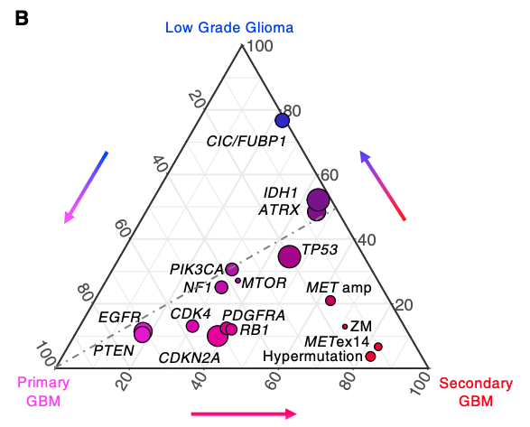

出自https://www.cell.com/cell/fulltext/S0092-8674(18)31250-9?_returnURL=https%3A%2F%2Flinkinghub.elsevier.com%2Fretrieve%2Fpii%2FS0092867418312509%3Fshowall%3Dtrue

原文解析：

- 点的坐标代表其突变频率，越靠近三角形的一个角，代表在这个类型突变越多；
- 点的大小代表在glioma这个病中，总共的突变频率；
- 颜色代表相对突变频率

## 应用场景

展示3种不同疾病或者3组之间某个指标的相关性，一目了然。

ggtern在文献中的应用：http://www.ggtern.com/publications/

带代码的更多主题：http://www.ggtern.com/posts/

关注“小丫画图”公众号，回复“三角形”查看ggtern在另一篇Cell paper中的用法及代码。

脑洞大开，发挥你的想象力，一定能拓展出更多应用场景。

## 环境设置

```r
#options("repos"= c(CRAN="https://mirrors.tuna.tsinghua.edu.cn/CRAN/"))
#options(BioC_mirror="http://mirrors.ustc.edu.cn/bioc/")
#devtools::install_git('https://bitbucket.org/nicholasehamilton/ggtern')
#install.packages("tidyverse")
#install.packages('ggtern')
#install.packages("proto")
#install.packages("directlabels")
library(ggtern)
citation(package = 'ggtern')
```

```
##
##
## Hamilton NE, Ferry M (2018). "ggtern: Ternary Diagrams Using
## ggplot2." _Journal of Statistical Software, Code Snippets_,
## *87*(3), 1-17. doi: 10.18637/jss.v087.c03 (URL:
## http://doi.org/10.18637/jss.v087.c03).
##
## A BibTeX entry for LaTeX users is
##
##   @Article{,
##     title = {{ggtern}: Ternary Diagrams Using {ggplot2}},
##     author = {Nicholas E. Hamilton and Michael Ferry},
##     journal = {Journal of Statistical Software, Code Snippets},
##     year = {2018},
##     volume = {87},
##     number = {3},
##     pages = {1--17},
##     doi = {10.18637/jss.v087.c03},
##   }
```

```r
library(tidyverse)
library(scales)
library(ggplot2)
library(directlabels)

Sys.setenv(LANGUAGE = "en") #显示英文报错信息
options(stringsAsFactors = FALSE) #禁止chr转成factor
```

## 输入数据预处理

如果你的数据已经整理成“easy_input.csv”的格式，就可以跳过这步，直接进入“输入文件”。

下载原文的补充材料Table2.pdf，整理为“not_easy_input.csv”

### 直接用原文数据画图

```r
df <- read.csv("not_easy_input.csv")
head(df)
```

```
##            Gene Altered.in.sGBM Total.of.sGBM Frequency.in.sGBM
## 1       METex14              11            78              0.14
## 2 Hypermutation              23           145              0.16
## 3            ZM               4            78              0.05
## 4 MET Amplified              17           145              0.12
## 5          ATRX              59           145              0.41
## 6          TP53              99           145              0.68
##   sGBM.Specificity Altered.in.pGBM Total.of.pGBM Frequency.in.pGBM
## 1            11.03               3           174              0.02
## 2            10.72               5           190              0.03
## 3             6.02               2           174              0.01
## 4             3.43               8           273              0.03
## 5             1.66              14           273              0.05
## 6             1.66              82           273              0.30
##   Altered.in.LGG Total.of.LGG Frequency.in.LGG
## 1              6          530             0.01
## 2              2          283             0.01
## 3              4          530             0.01
## 4             11          283             0.04
## 5            122          283             0.43
## 6            147          283             0.52
##   Alteration.Frequency.in.glioma
## 1                           0.03
## 2                           0.05
## 3                           0.01
## 4                           0.05
## 5                           0.28
## 6                           0.47
```

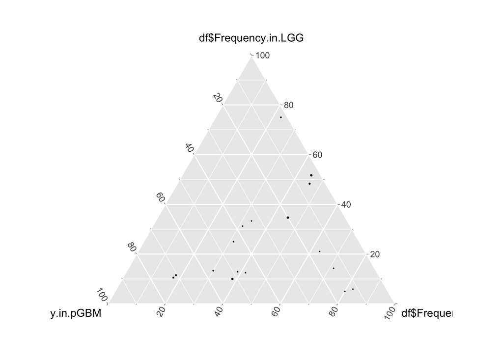

```r
ggtern(data=df, aes(x=df$Frequency.in.pGBM,
                    y=df$Frequency.in.LGG,
                    z=df$Frequency.in.sGBM)) +
   geom_point(size = df$Alteration.Frequency.in.glioma)
```

可以看到，点的大小和原文有较大出入，说明原文对数据进行了一定的优化。

### 把size扩大50倍

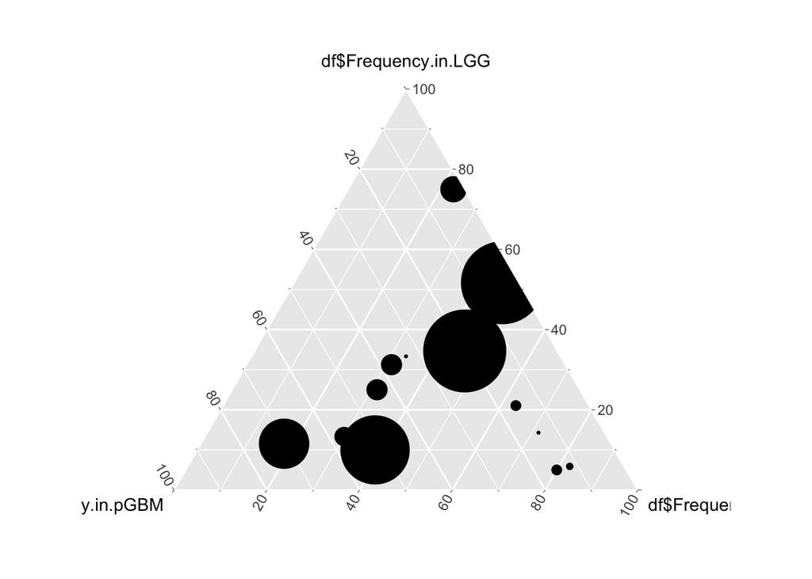

```r
ggtern(data=df,aes(x=df$Frequency.in.pGBM,y=df$Frequency.in.LGG,z=df$Frequency.in.sGBM)) +
   geom_point(size=df$Alteration.Frequency.in.glioma*50)
```

可以看到，除了几个较大的点，其他点大小同原文相似度极高，估计作者对特大值进行了不同的处理

### 分段处理

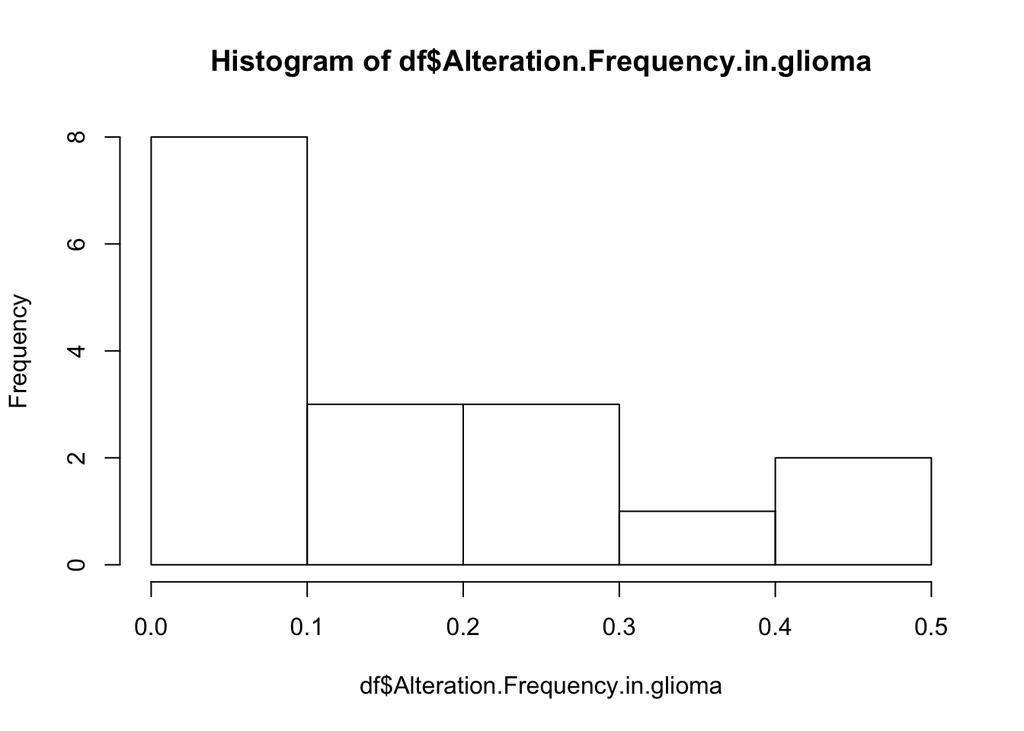

```r
#先查看分布
hist(df$Alteration.Frequency.in.glioma)
```

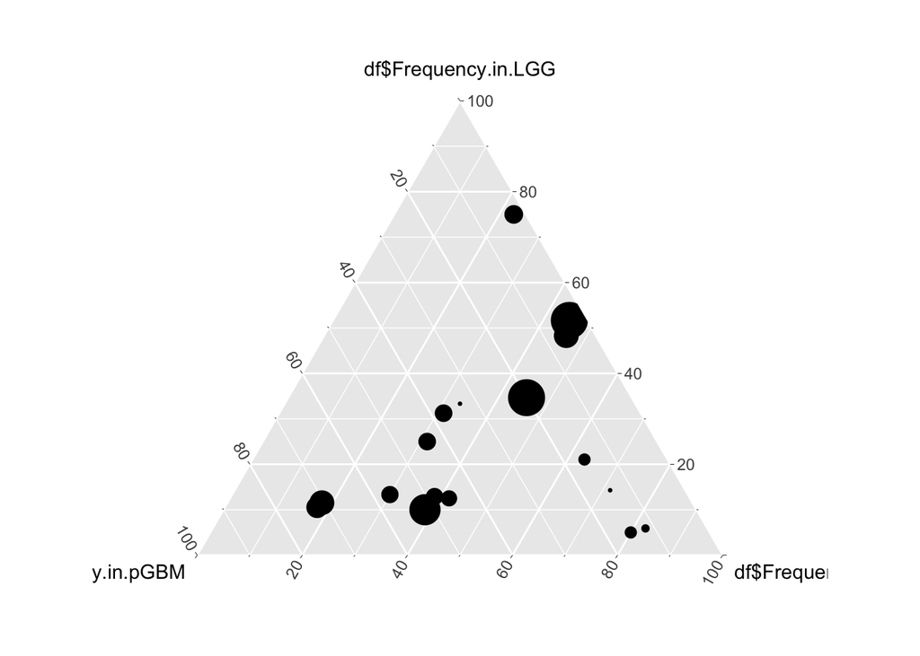

```r
#用0.1作为阈值来分段，
df$allfrequency <- ifelse(df$Alteration.Frequency.in.glioma >= 0.1,
                       10^(df$Alteration.Frequency.in.glioma) * 3,
                       50 * (df$Alteration.Frequency.in.glioma))

ggtern(data=df, aes(x=df$Frequency.in.pGBM,
                    y=df$Frequency.in.LGG,
                    z=df$Frequency.in.sGBM)) +
   geom_point(size=df$allfrequency)
```

```r
write.csv(df[,c(1,4,8,11,13)],"easy_input.csv", quote = F, row.names = F)
```

接下来就采用这种方式预处理输入数据，调整细节、美化图形。

## 输入文件

easy_input.csv：包含5列。

- 第1列，基因名；
- 第2、3、4列，对应xyz坐标。此处代表基因在GBM各亚型中的突变频率；
- 第5列，点的大小。此处代表基因在所有GBM中总的突变频率。

至少包含3列，即3个坐标：x，y，z，即可画出点在三角形的位置。

点的大小和颜色可以按照自己的生物学意义处理。

```r
df <- read.csv('easy_input.csv')
head(df)
```

```
##            Gene Frequency.in.sGBM Frequency.in.pGBM Frequency.in.LGG
## 1       METex14              0.14              0.02             0.01
## 2 Hypermutation              0.16              0.03             0.01
## 3            ZM              0.05              0.01             0.01
## 4 MET Amplified              0.12              0.03             0.04
## 5          ATRX              0.41              0.05             0.43
## 6          TP53              0.68              0.30             0.52
##   allfrequency
## 1     1.500000
## 2     2.500000
## 3     0.500000
## 4     2.500000
## 5     5.716382
## 6     8.853628
```

## 开始画图

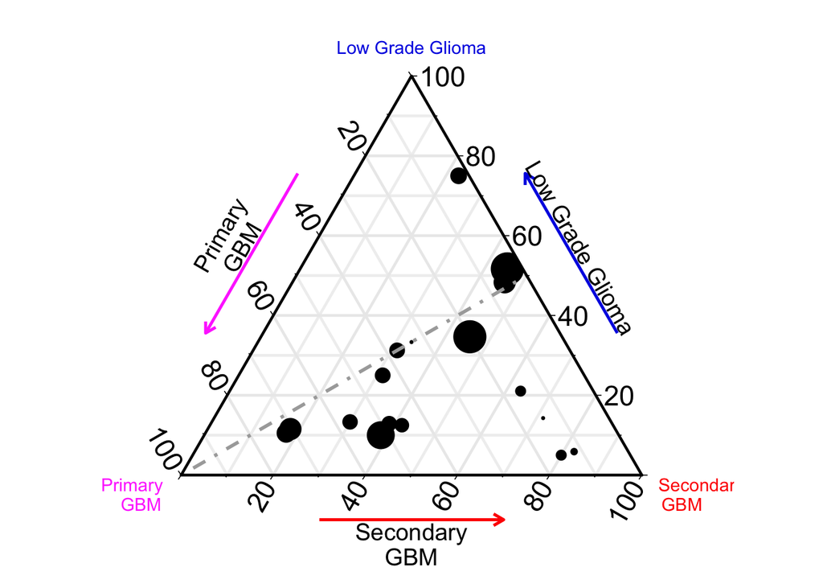

```r
p <- ggtern(data=df, aes(x=df$Frequency.in.pGBM, y=df$Frequency.in.LGG, z=df$Frequency.in.sGBM)) +
  geom_point(size = df$allfrequency) + #用allfrequency来定义点的大小
  theme_custom(18, '') + #字体大小
  labs(x='Primary\nGBM', z='Secondary\nGBM', y='Low Grade Glioma')+ #加label
  theme(tern.panel.background = element_rect(fill = "white"), #背景白色
                                            tern.panel.grid.minor = element_line(color = "gray90"), #背景网格颜色
                                            tern.axis.arrow.show = TRUE, #画箭头

        #箭头颜色和大小 L: LEFT, R: RIGHT, T: TOP
        tern.axis.arrow.T = element_line(color ='#0000E3', size = 2.5),
        tern.axis.arrow.L = element_line(color = '#FF44FF', size = 2.5),
        tern.axis.arrow.R = element_line(color = 'red', size = 2.5),

        #箭头上字的颜色
        tern.axis.arrow.text.L = element_text(color = 'black'),
        tern.axis.arrow.text.T = element_text(color = 'black'),
        tern.axis.arrow.text.R = element_text(color = 'black'),

        #箭头距离三角形的远近
        tern.axis.arrow.sep = 0.1,

        #背景网格颜色、线型、粗细
        tern.panel.grid.major.T = element_line(color = 'gray92', linetype = 1, size = 0.8),
        tern.panel.grid.major.L = element_line(color = 'gray92', linetype = 1, size = 0.8),
        tern.panel.grid.major.R = element_line(color = 'gray92', linetype = 1, size = 0.8),
        tern.panel.grid.minor.T = element_line(color = 'gray94', linetype = 1, size = 0.8),
        tern.panel.grid.minor.L = element_line(color = 'gray94', linetype = 1, size = 0.8),
        tern.panel.grid.minor.R = element_line(color = 'gray94', linetype = 1, size = 0.8),

        #坐标轴title的字体颜色、大小
        tern.axis.title.L = element_text(color = '#FF44FF', size = 11),
        tern.axis.title.T = element_text(color = '#0000E3', size = 11),
        tern.axis.title.R = element_text(color = 'red', size = 11),

        #坐标轴标签的字号
        tern.axis.text.L = element_text(size = 17,face = 'bold'),
        tern.axis.text.R = element_text(size = 17,face = 'bold'),
        tern.axis.text.T = element_text(size = 17,face = 'bold'),

        #整体画布往上移动一点，避免压到字
        tern.axis.vshift = 0.04,

        #坐标轴粗细
        tern.axis.line.T = element_line(size = 0.8),
        tern.axis.line.R = element_line(size = 0.8),
        tern.axis.line.L = element_line(size = 0.8)) +

  #画一条虚线
  geom_Lisoprop(color='darkgrey', value=.5, linetype=4, size=1)
p
```

### 给点加颜色

此处采用逐层上颜色，同时设置为半透明：

突变频率越高，则堆砌的颜色则越深，越有意义。

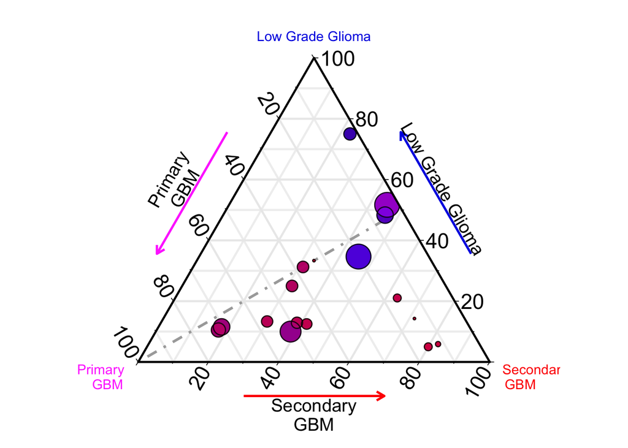

```r
p1 <- p +
  #分别画三种亚型的突变频率，图层叠加
  geom_point(aes(color=df$Frequency.in.sGBM), size=df$allfrequency, alpha=0.7) + #半透明
  geom_point(aes(color=df$Frequency.in.pGBM), size=df$allfrequency, alpha=0.7) +
  geom_point(aes(color=df$Frequency.in.LGG), size=df$allfrequency, alpha=0.7) +
  scale_color_gradient2(low='red', mid = '#0000E3', high ='purple', midpoint = 0.33, #三种颜色
                        guide = FALSE) + #不画图例

  #每个圈圈外面加个黑圈
  geom_point(size=df$allfrequency, shape = 1, alpha = 0.8,
             stroke = 0.7, #线的粗细
             color = "black")
p1
```

```r
#保存到pdf文件
ggsave("triangle.pdf")
```

### 标基因名

为了避免基因名的重叠，我们通常会使用ggrepel，可惜ggrepel不支持ggtern。另外，geom_text的check_overlap也对ggtern无效。提供以下两种方案来解决字的重叠问题：

#### 方案一：geom_text + AI

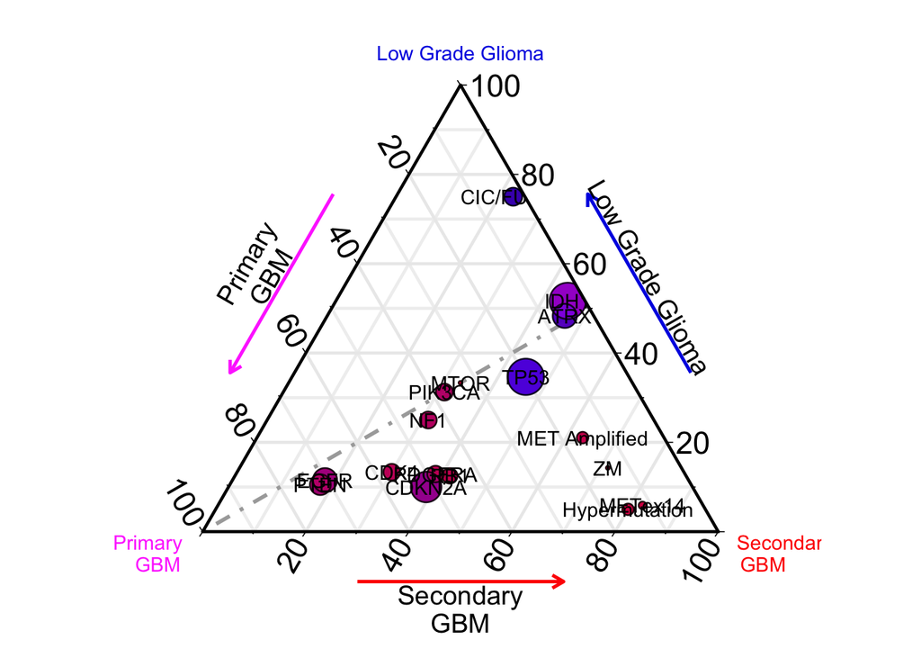

```r
p1 + geom_text(aes(label=Gene))
```

```r
ggsave('triangle_geom_text.pdf')
```

优点：能标出全部基因名

缺点：需要用Illustrator打开pdf文件，然后用鼠标拖动基因名来微调。

#### 方案二：用directlabels包

参考这篇：https://mp.weixin.qq.com/s/6MMVsO22n9oKZNC7qC7g5A

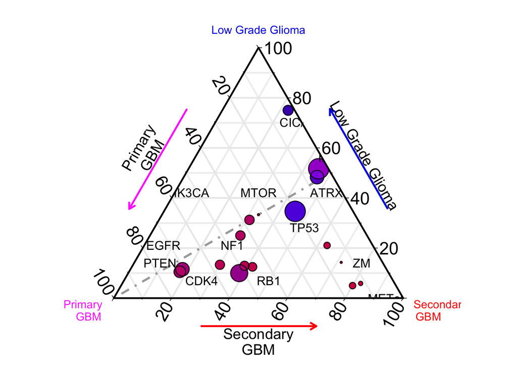

```r
p1 + geom_dl(aes(label=Gene), method = "smart.grid")
```

```r
ggsave('triangle_directlabels.pdf')
```

优点：大部分基因名分散较好

缺点：包里的参数有限。基因名离基因较远，需要参照方案一核对基因跟点的对应关系。另外，边缘的基因名溢出。因此，需要借用Illustrator微调。